# Posterior with Exponential Growth

Andrea Brizzi

01/04/2021

First let us introduce some code that specifies the parameters of the epidemic we want to consider.

```r
# Epidemic settings
I_0 = 2
R0 = 2.5
mean_gi = 6.5
sd_gi = sqrt(3^2+3.5^2)

# reparametrisation
shape = (mean_gi/sd_gi)^2
scale = sd_gi^2/mean_gi

# r-R0 relations obtained through Lotka-Euler equation
r = (R0^(1/shape) - 1)/scale
series <- function(r, theta = scale, k = shape){(1 + theta*r )^{k}}
```

We can compute the exact EpiEstim posterior in a scenario of exponential growth. In particular, let us focus on the first window of length 7. The posterior shape is given by:
$$a_{post} = a_{prior} + \sum_{ s = 1 }^7 I_s = 1 + I_0 \sum_{ s = 1 }^7 e^{rs}
= 1 + I_0 e^r \frac{(1-e^{7r})}{1-e^r}$$
The posterior scale is given by:
$$b_{post}^{-1} = b_{prior}^{-1} + \sum_{ s = 1 }^7 \Lambda_s,$$
where $\Lambda_s$ is the measure of infectiousness, defined as the convolution of past infections and serial interval distribution ($\underline{w}$). (Note that the implementation in EpiEstim may only count local infections inside this, and not imported, but need-a check).
$$\Lambda_s = \sum_{l = 1}^s w_l I_{s-l} = I_0 e^{rs} \sum_{l = 1}^s w_l e^{-rl}.$$

Summing for all relevant values of $s$ yields:

$$\begin{align}
\sum_{s=1}^7 \Lambda_s &= I_0 \sum_{s=1}^7 e^{rs} \sum_{l = 1}^s w_l e^{-rl} \\
&= I_0 \sum_{l = 1}^7 w_l e^{-rl} \sum_{s=l}^7 e^{rs} \\
&= I_0 \sum_{l = 1}^7 w_l e^{-rl} e^{-rl}\sum_{s=0}^{7-l} e^{rs} \\
&= \frac{I_0}{1-e^r} \sum_{l = 1}^7 w_l e^{-2rl} (1-e^{r(8-l)}) \\
&= \frac{I_0}{1-\gamma} \sum_{l = 1}^7 w_l \gamma^{-2l} (1-\gamma^{8-l}). \\
\end{align}$$

Let us see if indeed these values yield to the posteriors estimated by EpiEstim.

```r
a_post <- function(a_prior = 1,r_v = r, I_0_v = I_0){
  a_prior + I_0_v * exp(r_v) * (1-exp(7*r_v))/(1-exp(r_v))
}

b_post <- function(b_prior = 5, r_v = r, I_0_v = I_0){

  w <- discr_si(k = 1:7, mu = 6.5, sigma = sqrt(9+12.25))
  gamma <- exp(r_v)
  sum_lambda <- I_0_v/(1-gamma)*sum(w* gamma^{-2*1:7}*(1-gamma^{8-1:7}))

  (b_prior + sum_lambda)^-1
}

a_post()*b_post()
```

```
## [1] 3.896981
```

Now compare with EpiEstim output.

```r
# compare the results to EpiEstim
t_start <- 2
t_end <- 8
I <- I_0*exp(r*1:7)

ep1 <- EpiEstim::estimate_R(c(I_0,I), method = "parametric_si",
                           config = make_config(
                             list(
                               mean_si = 6.5,
                               std_si = sqrt(3^2+3.5^2),
                               t_start = 2,
                               t_end = 8
                             )))$R
ep1$`Mean(R)`
```

```
## [1] 3.837223
```

The two are not exactly identical, but they are very very similar. I think a difference lies in the fact that infections are split into local ones and imported ones. The imported cases might not enter into the previous formulae.

# Why are we overestimating?

The measure of infectiousness is not appropriate in an exponential growth scenario.

In the first few days, EpiEstim does not find plausible generators of the past infections, and so explains the `larger’ observed cases by a larger $R_0$! This can be readily fixed though, by noting that the “true” infectiousness of the population in an exponential growth scenario is:

$$\Lambda_s^{\infty} = I_s \int_{l=0}^{\infty} w(l)e^{-rl} dl = I_s * R_0^{-1}$$
So that:
$$\sum_{s=1}^7 \Lambda_s^{\infty} = R_0^{-1} * \sum_{s=1}^7 I_s^{\infty}$$

A “flat prior” with $a = b = 0$ would yield $R_0$ as posterior mean. Using the default priors, the posterior mean is given by:
$$\mu_{post} = a_{post} \cdot b_{post} =
\left(1 + I_0 e^r \frac{(1-e^{7r})}{1-e^r} \right)
\frac{1}{5^{-1} + R_0^{-1} I_0 e^r \frac{(1-e^{7r})}{1-e^r}}$$

And the standard deviation:
$$\sigma_{post} = \sqrt{a_{post}} \cdot b_{post}$$

We can plot the results to see how the results of EpiEstim would change with my correction.

```r
t = 10
I0 = 2*exp(r*(1:t))
sum_infections <- I0 * exp(r) * (1-exp(7*r))/(1-exp(r))
a_post = 1 + sum_infections
b_post = (R0^{-1}*sum_infections)^-1

posterior <- data.frame(
  time = 1:t,
  mu = a_post*b_post,
  sigma = sqrt(a_post)*b_post,
  median = qgamma(.5, shape = a_post, scale=b_post),
  q_.975 = qgamma(.975, shape = a_post, scale=b_post),
  q_.025 = qgamma(.025, shape = a_post, scale=b_post),
  method = 'adjusted'
)

# Try and get the same for EpiEstim
I <- c(2, I0, 2*exp(r*(1+t:(t+6))))
t_start = 2:11
t_end = 8:17
ep <- EpiEstim::estimate_R(c(2,I), method = "parametric_si",
                           config = make_config(
                             list(
                               mean_si = 6.5,
                               std_si = sqrt(3^2+3.5^2),
                               t_start = t_start,
                               t_end = t_end
                             )))$R
```

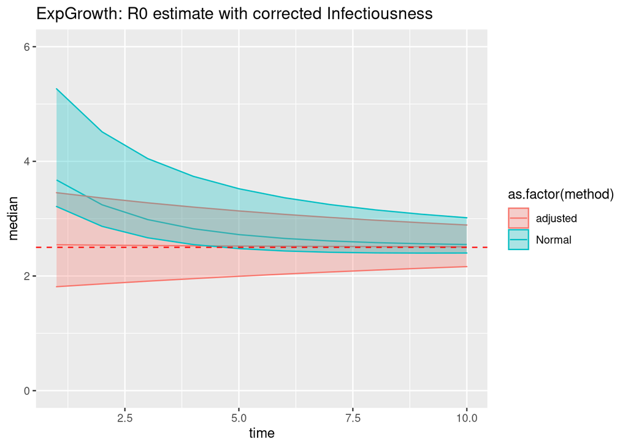

```r
ep <- data.frame(time = 1:t,
                 mu = ep$`Mean(R)`,
                 sigma = ep$`Std(R)`,
                 median = ep$`Median(R)`,
                 q_.975 = ep$`Quantile.0.975(R)`,
                 q_.025 = ep$`Quantile.0.25(R)`,
                 method = 'Normal')

posterior <- rbind(posterior, ep)


ggplot(posterior, aes(x = time, group = as.factor(method), col = as.factor(method), fill = as.factor(method)))+
  geom_line(aes(y = median)) +
  geom_ribbon(aes(ymin = q_.025, ymax = q_.975), alpha = .3) +
  geom_hline(aes(yintercept = R0), linetype = "dashed", col = "red") +
  ylim(c(0,6)) + ggtitle("ExpGrowth: R0 estimate with corrected Infectiousness")
```